# Draft Data Analysis and Report

Trent Meyer

2022-11-19

# Introduction

Our data comes from the New York State Department of Health public database, which was completed over fourteen years from 2008 to 2021. They collected samples at sites throughout the 62 counties in New York state, recording the total ticks collected, tick population density, along with percentages of those ticks collected who were found to have specific bacteria or parasites.

With data over many years, it would be interesting to look at if there is a difference in the Tick.Population.Density between the beginning year (2008) and the end year (2021). Independence between the two population densities would be more reasonable since the years are not closer together. Richard E.L. Paul, et. al., explain how their experiment yielded no changes in adult tick populations over time (2016). This would lead a look into the year and density to see if there is actually a difference or not.

One idea to look into is that certain regions of New York State that may be more urbanized than others to see if the Tick.Population.Density differs compared to more rural regions. Paul (2016) describes that ticks’ natural habitat are often forests where they come into contact with their hosts. Regions such as the North Country or Southern Tier, which are more rural compared to say NYC, have larger areas of forests which could mean higher tick population density.

With the urbanization of many areas, ticks often find their way into suburban areas through nearby forests which house the ticks being used by domesticated pets and children (Paul 2016). This would lead a discussion about whether region and year are affecting the tick population density for the years 2008 and 2021. If areas are becoming more urbanized over time, that means that more ticks are possibly finding their way into cities.

Many individuals in rural areas are aware of ticks, how to get rid of them, and where to find them. However, many individuals in cities are not as aware of ticks, and may not realize that ticks can carry bacteria or parasites that can cause harmful diseases. Kowalec et. al., explain that species of bacteria or parasites can “differ between natural and urban areas”(2017). With this in mind, we can expect a possible difference between these bacteria and parasites while looking at years. Taking into account the urbanization of many areas, it could be possible to see more ticks with specific bacteria or parasites being found in more areas than say a decade ago.

# Analysis

Let’s clear the environment, load in packages, and read in the tick data:

```r
rm(list = ls())
library(tidyverse)
library(here)
library(ggfortify)
library(lubridate)
tick_adult <- read.csv(here("Data", "Deer_Tick_Surveillance__Adults__Oct_to_Dec__excluding_Powassan_virus__Beginning_2008.csv"))
```

Let’s take a look at the data!

```r
head(tick_adult)
```

```
##   Year     County Total.Sites.Visited Total.Ticks.Collected
## 1 2021     Albany                   4                   366
## 2 2021 Chautauqua                   3                   199
## 3 2021   Dutchess                   5                   438
## 4 2021     Warren                   4                    88
## 5 2020     Albany                   4                   114
## 6 2020    Chemung                   1                   271
##   Tick.Population.Density Total.Tested B..burgdorferi....
## 1                   85.83          168               53.6
## 2                   36.70          107               56.1
## 3                   66.80           51               47.1
## 4                   13.85           87               41.4
## 5                   37.15          103               71.8
## 6                  256.90           50               56.0
##   A..phagocytophilum.... B..microti.... B..miyamotoi....
## 1                   12.5            9.5              2.4
## 2                    0.0            0.0              0.0
## 3                   11.8           11.8              5.9
## 4                    6.9            9.2              2.3
## 5                   13.6            8.7              0.0
## 6                   16.0            0.0              2.0
##             County.Centroid
## 1 (42.5882713, -73.9740136)
## 2 (42.3042159, -79.4075949)
## 3 (41.7550085, -73.7399512)
## 4 (43.5551053, -73.8381388)
## 5 (42.5882713, -73.9740136)
## 6 (42.1552807, -76.7471788)
```

```r
glimpse(tick_adult)
```

```
## Rows: 547
## Columns: 11
## $ Year                    <int> 2021, 2021, 2021, 2021, 2020, 2020, 2020, 2020…
## $ County                  <chr> "Albany", "Chautauqua", "Dutchess", "Warren", …
## $ Total.Sites.Visited     <int> 4, 3, 5, 4, 4, 1, 3, 1, 1, 1, 1, 1, 1, 1, 1, 1…
## $ Total.Ticks.Collected   <int> 366, 199, 438, 88, 114, 271, 75, 131, 157, 51,…
## $ Tick.Population.Density <dbl> 85.83, 36.70, 66.80, 13.85, 37.15, 256.90, 21.…
## $ Total.Tested            <int> 168, 107, 51, 87, 103, 50, 69, 44, 50, 50, 50,…
## $ B..burgdorferi....      <dbl> 53.6, 56.1, 47.1, 41.4, 71.8, 56.0, 68.1, 59.1…
## $ A..phagocytophilum....  <dbl> 12.5, 0.0, 11.8, 6.9, 13.6, 16.0, 10.1, 36.4, …
## $ B..microti....          <dbl> 9.5, 0.0, 11.8, 9.2, 8.7, 0.0, 0.0, 0.0, 0.0, …
## $ B..miyamotoi....        <dbl> 2.4, 0.0, 5.9, 2.3, 0.0, 2.0, 1.4, 2.3, 0.0, 0…
## $ County.Centroid         <chr> "(42.5882713, -73.9740136)", "(42.3042159, -79…
```

```r
str(tick_adult)
```

```
## 'data.frame':    547 obs. of  11 variables:
##  $ Year                   : int  2021 2021 2021 2021 2020 2020 2020 2020 2020 2020 ...
##  $ County                 : chr  "Albany" "Chautauqua" "Dutchess" "Warren" ...
##  $ Total.Sites.Visited    : int  4 3 5 4 4 1 3 1 1 1 ...
##  $ Total.Ticks.Collected  : int  366 199 438 88 114 271 75 131 157 51 ...
##  $ Tick.Population.Density: num  85.8 36.7 66.8 13.8 37.1 ...
##  $ Total.Tested           : int  168 107 51 87 103 50 69 44 50 50 ...
##  $ B..burgdorferi....     : num  53.6 56.1 47.1 41.4 71.8 56 68.1 59.1 48 46 ...
##  $ A..phagocytophilum.... : num  12.5 0 11.8 6.9 13.6 16 10.1 36.4 0 6 ...
##  $ B..microti....         : num  9.5 0 11.8 9.2 8.7 0 0 0 0 0 ...
##  $ B..miyamotoi....       : num  2.4 0 5.9 2.3 0 2 1.4 2.3 0 0 ...
##  $ County.Centroid        : chr  "(42.5882713, -73.9740136)" "(42.3042159, -79.4075949)" "(41.7550085, -73.7399512)" "(43.5551053, -73.8381388)" ...
```

Let’s rename the parasite and bacteria variables, and also read in County and Year as factors instead of characters:

```r
tick_adult <- tick_adult %>%
  rename(B.burgdorferi = "B..burgdorferi....",
         A.phagocytophilum = "A..phagocytophilum....",
         B.microti = "B..microti....",
         B.miyamotoi = "B..miyamotoi....") %>%
  mutate(County = as.factor(County),
         Year = as.factor(Year))
```

Tick population density makes sense as a response variable, rather than total tick population. Let’s graph tick population density to see what the distribution looks like.

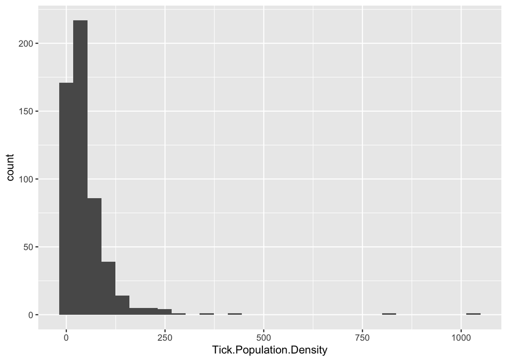

```r
ggplot(data = tick_adult, aes(x = Tick.Population.Density)) +
  geom_histogram()
```

We see that there are two that have a Tick.Population.Density > 750. I am not sure if this is a mistake, or if they actually found this high of a tick population density. Let’s remove these observations from the data.

```r
tick_adult <- tick_adult %>% filter(Tick.Population.Density < 750)
```

Let’s replot the distribution of Tick.Population.Density:

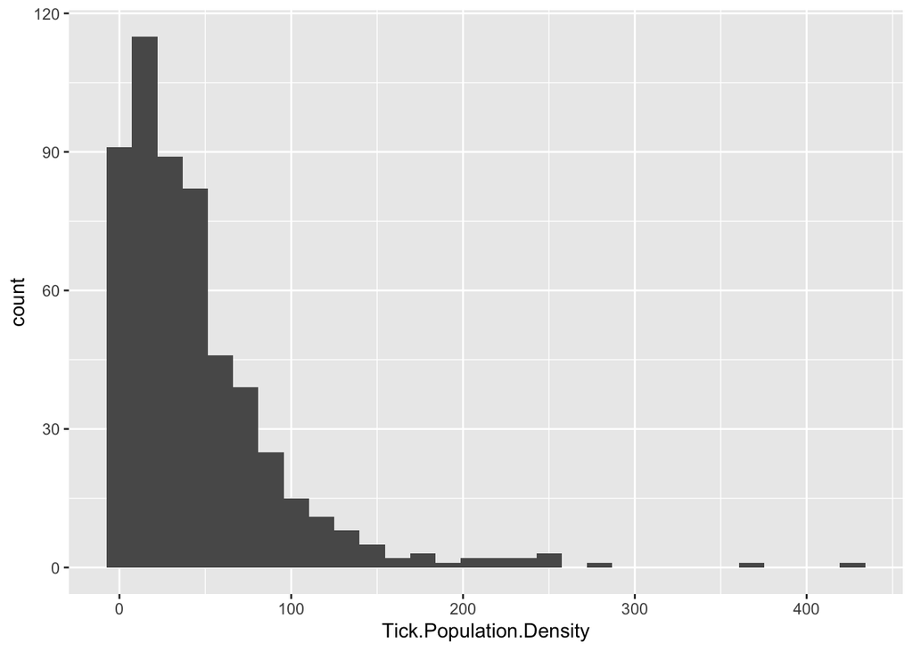

```r
ggplot(data = tick_adult, aes(x = Tick.Population.Density)) +
  geom_histogram()
```

We can see that the data is right-skewed.

```r
summary(tick_adult)
```

```
##       Year          County    Total.Sites.Visited Total.Ticks.Collected
##  2014   : 52   Albany  : 14   Min.   : 1.000      Min.   :    0.0
##  2015   : 52   Columbia: 14   1st Qu.: 1.000      1st Qu.:   54.0
##  2020   : 50   Dutchess: 14   Median : 2.000      Median :  101.0
##  2016   : 49   Monroe  : 14   Mean   : 2.494      Mean   :  169.6
##  2017   : 49   Orange  : 14   3rd Qu.: 3.000      3rd Qu.:  158.0
##  2021   : 45   Oswego  : 14   Max.   :28.000      Max.   :11260.0
##  (Other):247   (Other) :460
##  Tick.Population.Density  Total.Tested    B.burgdorferi    A.phagocytophilum
##  Min.   :  0.00          Min.   :  0.00   Min.   :  0.00   Min.   : 0.000
##  1st Qu.: 14.09          1st Qu.: 50.00   1st Qu.: 37.50   1st Qu.: 0.000
##  Median : 32.45          Median : 51.00   Median : 50.30   Median : 3.800
##  Mean   : 45.16          Mean   : 75.02   Mean   : 46.75   Mean   : 6.295
##  3rd Qu.: 60.00          3rd Qu.: 98.00   3rd Qu.: 58.90   3rd Qu.:11.600
##  Max.   :426.70          Max.   :500.00   Max.   :100.00   Max.   :44.100
##                                           NA's   :27       NA's   :27
##    B.microti       B.miyamotoi     County.Centroid
##  Min.   : 0.000   Min.   : 0.000   Length:544
##  1st Qu.: 0.000   1st Qu.: 0.000   Class :character
##  Median : 0.000   Median : 0.500   Mode  :character
##  Mean   : 2.912   Mean   : 1.168
##  3rd Qu.: 4.000   3rd Qu.: 2.000
##  Max.   :32.000   Max.   :10.000
##  NA's   :27       NA's   :218
```

We will use tick population density as the response for most of the statistical tests.

## Is there significant difference in Tick.Population.Density between the first year (2008), and last year (2021)?

I am going to subset the data to only have the observations for the years 2008 and 2021.

```r
tick_adult_small <- tick_adult %>% filter(Year == "2008" | Year == "2021")
```

Now I want to group by the year and find the mean Tick.Population.Density for both of the years.

```r
tick_adult_small_total <- tick_adult_small %>% group_by(Year) %>% summarise(mean_density = mean(Tick.Population.Density, na.rm = T))
```

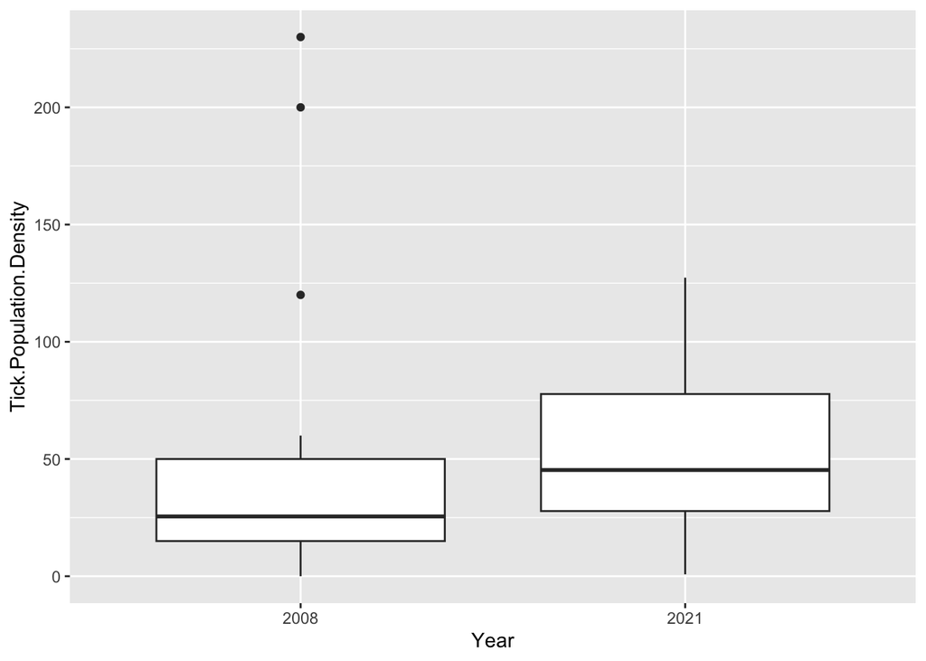

```r
ggplot(data = tick_adult_small, aes(x = Year, y = Tick.Population.Density)) +
  geom_boxplot()
```

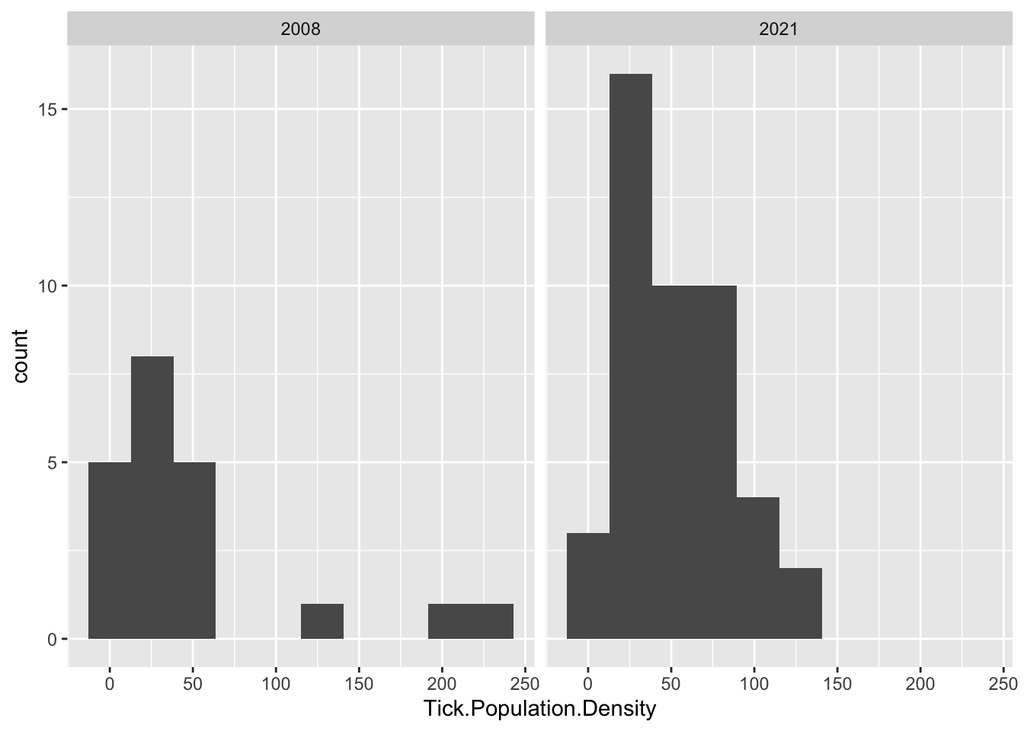

```r
ggplot(data = tick_adult_small, aes(x = Tick.Population.Density)) +
  geom_histogram(bins = 10) +
  facet_wrap(~Year)
```

There is a bit of overlap in the spread of each year, however it looks like the mean is higher for 2021 compared to 2008. These plots are much easier to read with the few observations out that were making it difficult to read and compare between years. The histograms show that the peaks are in slightly different location on the x-axis.

I think the way I have set this up, I am going to have to run a two-sample t-test with the following hypotheses:

–Null Hypothesis: There is no true difference in mean Tick.Population.Density between 2008 and 2021.

–Alternative Hypothesis: There is a true difference in mean Tick.Population.Density between 2008 and 2021.

Let’s run the two-sample t-test:

```r
year_ttest <- t.test(Tick.Population.Density ~ Year, data = tick_adult_small)
```

## Is there an association between Tick.Population.Density and Region (instead of county)?

Let’s plot the relationship between Tick.Population.Density and County

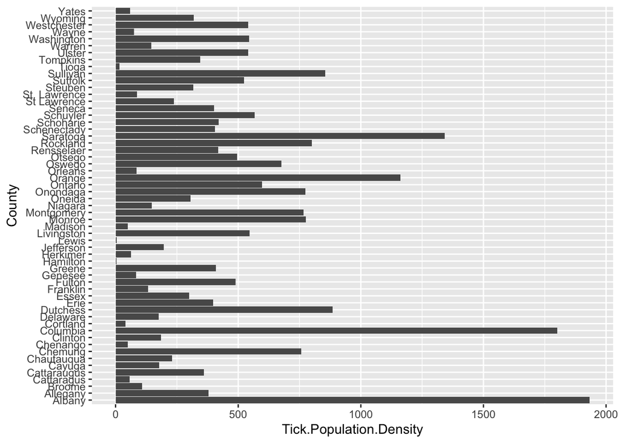

```r
ggplot(data = tick_adult, aes(x = County, y = Tick.Population.Density)) +
  geom_col() +
  coord_flip()
```

This plot and question are difficult to answer so I think I am going to create a variable for Region, and test if there is a difference between the 9 regions in NYS. Also, we can see that there are two levels for St. Lawrence County, so let’s combine those to both be in the North Country region.

```r
tick_adult <- tick_adult %>% mutate(Region = case_when(
  County == "Suffolk" | County == "Nassau" ~ "Long Island",

  County == "Brooklyn" | County == "Bronx" | County == "Manhattan" |
    County == "Staten Island" | County == "Queens" ~ "New York City",

  County == "Dutchess" | County == "Orange" | County == "Putnam" |
    County == "Rockland" | County == "Sullivan" | County == "Ulster" |
    County == "Westchester" ~ "Hudson Valley",

  County == "Niagara" | County == "Erie" | County == "Chautauqua" |
    County == "Cattaragus" | County == "Cattaraugus" |
    County == "Allegany" ~ "Western New York",

  County == "Orleans" | County == "Genesee" | County == "Wyoming" |
    County == "Monroe" | County == "Livingston" | County == "Wayne" |
    County == "Ontario" | County == "Yates" | County == "Seneca" ~ "Finger Lakes",

  County == "Steuben" | County == "Schuyler" | County == "Chemung" |
    County == "Tompkins" | County == "Tioga" | County == "Chenango"
  | County == "Broome" | County == "Delaware" ~ "Southern Tier",

  County == "Cortland" | County == "Cayuga" | County == "Onondaga" |
    County == "Oswego" | County == "Madison" ~ "Central New York",

  County == "St. Lawrence" | County == "St Lawrence" | County == "Lewis" |
    County == "Jefferson" | County == "Hamilton" | County == "Essex" |
    County == "Clinton" | County == "Franklin" ~ "North Country",

  County == "Oneida" | County == "Herkimer" | County == "Fulton" |
    County == "Montgomery" | County == "Otsego" |
    County == "Schoharie" ~ "Mohawk Valley",

  County == "Albany" | County == "Columbia" | County == "Greene" |
    County == "Warren" | County == "Washington" | County == "Saratoga" |
    County == "Schenectady" | County == "Rensselaer" ~ "Capital District"
))
```

Oof, that was a lot about code, now let’s replot this by Region!

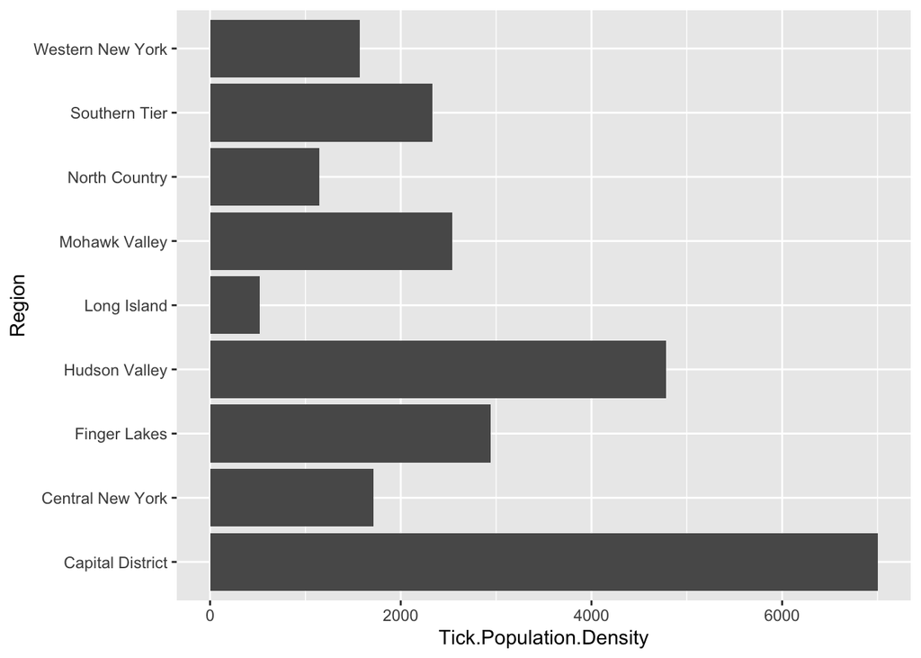

```r
ggplot(data = tick_adult, aes(x = Region, y = Tick.Population.Density)) +
  geom_col() +
  coord_flip()
```

It looks like there are possible differences, with Capital Region being much higher, and also possibly Hudson Valley have a higher density? Long Island seems to have a pretty low tick density.

Since we have a categorical predictor with at least three levels (Region) and a quantitative response, I think the best test would be an ANOVA. First we have to fit the model:

– Ho: There is no difference in Region mean Tick.Population.Density

– Ha: There is a difference in Region mean Tick.Population.Density

```r
region_mod <- lm(Tick.Population.Density ~ Region, data = tick_adult)
```

Then we need to check the assumptions:

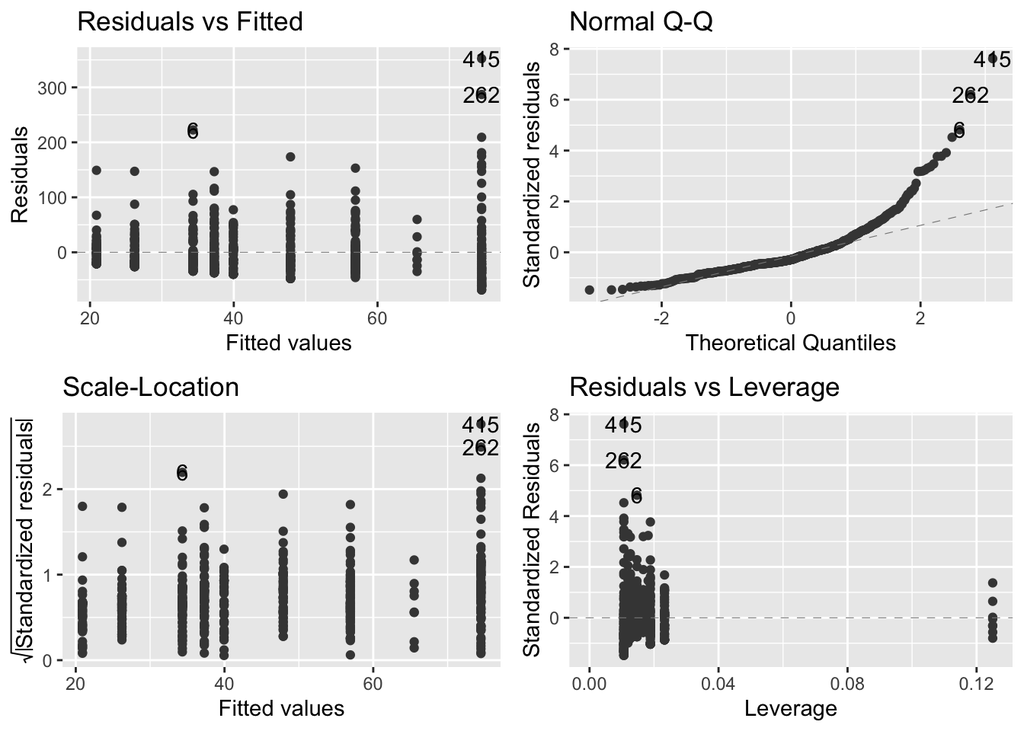

```r
autoplot(region_mod, smooth.colour = NA)
```

This is difficult because we do need see very much of a line in the Normal Q-Q plot, meaning the normality assumption is not perfect. Also, we do not see the constant variance in the Res vs Fitted plot, but this is a little bit better than the normality.

```r
region_mod_summary <- summary(region_mod)
region_anova <- anova(region_mod)
```

## Is there a difference in the Tick.Population.Density between the years 2008 and 2021 and Region?

```r
tick_adult_total <- tick_adult %>% group_by(Region, Year) %>% summarise(total_ticks_collected = sum(Total.Ticks.Collected))
```

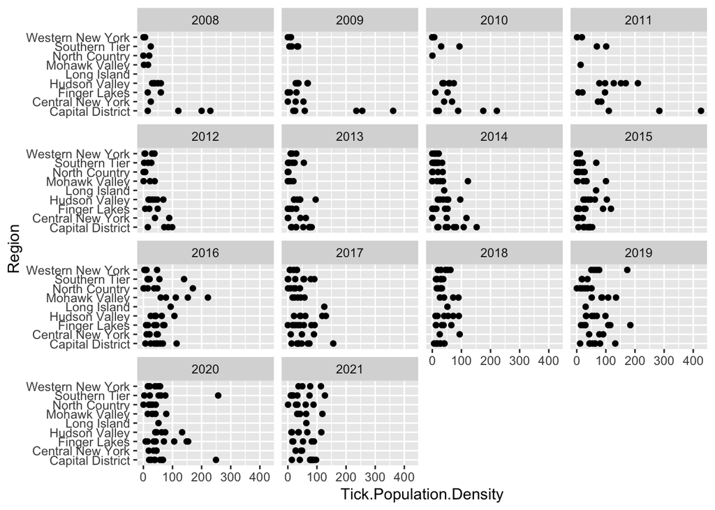

```r
ggplot(data = tick_adult, aes(x = Region, y = Tick.Population.Density)) +
  geom_point() +
  coord_flip() +
  facet_wrap(~Year)
```

```r
tick_adult_small <- tick_adult %>% mutate(Region = case_when(
  County == "Suffolk" | County == "Nassau" ~ "Long Island",

  County == "Brooklyn" | County == "Bronx" | County == "Manhattan" |
    County == "Staten Island" | County == "Queens" ~ "New York City",

  County == "Dutchess" | County == "Orange" | County == "Putnam" |
    County == "Rockland" | County == "Sullivan" | County == "Ulster" |
    County == "Westchester" ~ "Hudson Valley",

  County == "Niagara" | County == "Erie" | County == "Chautauqua" |
    County == "Cattaragus" | County == "Cattaraugus" |
    County == "Allegany" ~ "Western New York",

  County == "Orleans" | County == "Genesee" | County == "Wyoming" |
    County == "Monroe" | County == "Livingston" | County == "Wayne" |
    County == "Ontario" | County == "Yates" | County == "Seneca" ~ "Finger Lakes",

  County == "Steuben" | County == "Schuyler" | County == "Chemung" |
    County == "Tompkins" | County == "Tioga" | County == "Chenango"
  | County == "Broome" | County == "Delaware" ~ "Southern Tier",

  County == "Cortland" | County == "Cayuga" | County == "Onondaga" |
    County == "Oswego" | County == "Madison" ~ "Central New York",

  County == "St. Lawrence" | County == "St Lawrence" | County == "Lewis" |
    County == "Jefferson" | County == "Hamilton" | County == "Essex" |
    County == "Clinton" | County == "Franklin" ~ "North Country",

  County == "Oneida" | County == "Herkimer" | County == "Fulton" |
    County == "Montgomery" | County == "Otsego" |
    County == "Schoharie" ~ "Mohawk Valley",

  County == "Albany" | County == "Columbia" | County == "Greene" |
    County == "Warren" | County == "Washington" | County == "Saratoga" |
    County == "Schenectady" | County == "Rensselaer" ~ "Capital District"
))

tick_adult_small <- tick_adult_small %>% filter(Year == "2008" | Year == "2021")
```

```r
full_mod <- glm(Tick.Population.Density ~ Region + Year + Region*Year, data = tick_adult_small)
summary(full_mod)
```

```
##
## Call:
## glm(formula = Tick.Population.Density ~ Region + Year + Region *
##     Year, data = tick_adult_small)
##
## Deviance Residuals:
##      Min        1Q    Median        3Q       Max
## -126.250   -18.158    -0.533    14.654    88.750
##
## Coefficients: (1 not defined because of singularities)
##                                 Estimate Std. Error t value Pr(>|t|)
## (Intercept)                      141.250     19.156   7.374 1.75e-09 ***
## RegionCentral New York          -115.750     42.834  -2.702 0.009434 **
## RegionFinger Lakes              -103.750     33.179  -3.127 0.002969 **
## RegionHudson Valley              -96.817     24.730  -3.915 0.000279 ***
## RegionLong Island                 -6.705     40.636  -0.165 0.869621
## RegionMohawk Valley             -132.250     33.179  -3.986 0.000223 ***
## RegionNorth Country             -131.250     33.179  -3.956 0.000246 ***
## RegionSouthern Tier             -115.950     42.834  -2.707 0.009320 **
## RegionWestern New York          -138.683     29.261  -4.740 1.88e-05 ***
## Year2021                         -71.055     23.461  -3.029 0.003912 **
## RegionCentral New York:Year2021   82.628     48.838   1.692 0.097022 .
## RegionFinger Lakes:Year2021       85.209     39.722   2.145 0.036927 *
## RegionHudson Valley:Year2021      73.585     32.244   2.282 0.026862 *
## RegionLong Island:Year2021            NA         NA      NA       NA
## RegionMohawk Valley:Year2021     117.102     39.102   2.995 0.004297 **
## RegionNorth Country:Year2021     103.291     39.722   2.600 0.012277 *
## RegionSouthern Tier:Year2021      92.008     47.569   1.934 0.058875 .
## RegionWestern New York:Year2021  137.723     37.505   3.672 0.000594 ***
## ---
## Signif. codes:  0 '***' 0.001 '**' 0.01 '*' 0.05 '.' 0.1 ' ' 1
##
## (Dispersion parameter for gaussian family taken to be 1467.785)
##
##     Null deviance: 126257  on 65  degrees of freedom
## Residual deviance:  71921  on 49  degrees of freedom
## AIC: 684.88
##
## Number of Fisher Scoring iterations: 2
```

I can see here that the p-value for the Long Island Region is not significant at all, instead it is a very large p-value. The only other terms that are not significant are the interaction terms between Long Island-2021, Southern Tier-2021, and CNY-2021 are not significant. All of the others are significant at the 5% level.

## Is there a difference between mean B.burgdorferi percentage in the years 2008 and 2021?

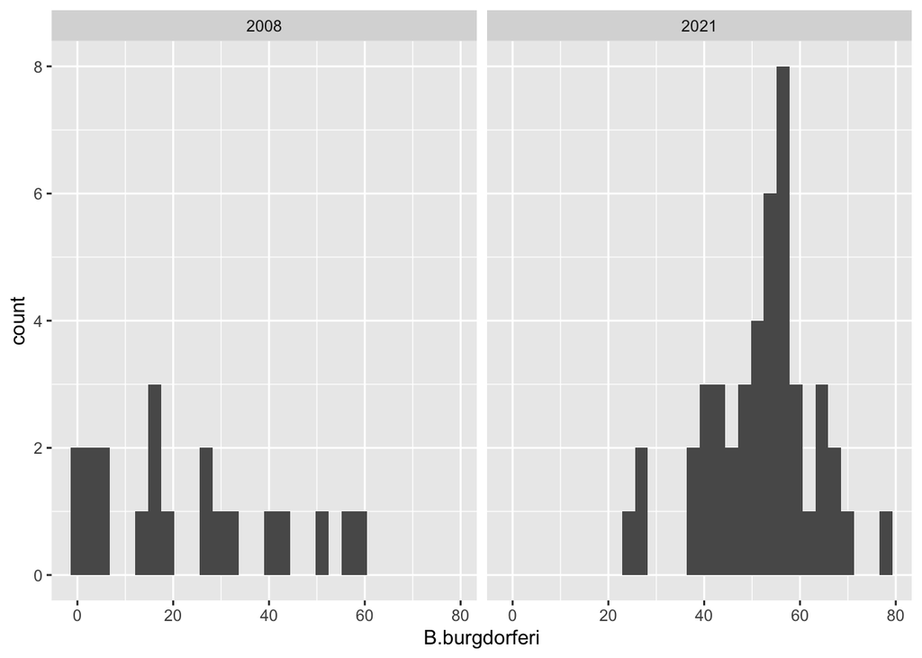

```r
ggplot(data = tick_adult_small, aes(x = B.burgdorferi)) +
  geom_histogram() +
  facet_wrap(~Year)
```

This will lead me to run a two-sample t-test with the following hypotheses:

Null Hypothesis: There is no difference in mean B.burgdorferi percentage between the years 2008 and 2021. Alternative Hypothesis: There is a difference in mean B.burgdorferi percentage between the years 2008 and 2021.

```r
bburg_ttest <- t.test(B.burgdorferi ~ Year, data = tick_adult_small)
```

## Is there a difference between mean A.phagocytophilum percentage in the years 2008 and 2021?

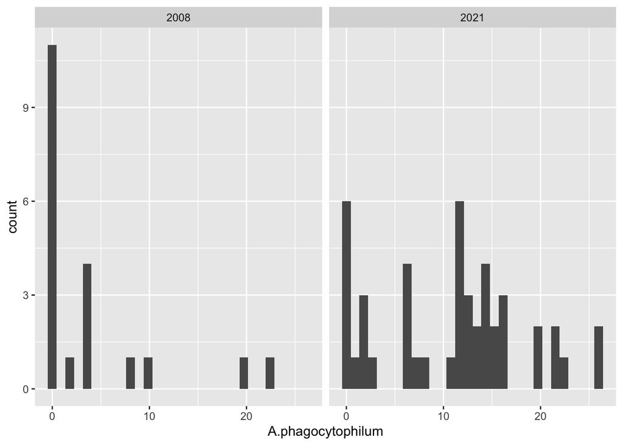

```r
ggplot(data = tick_adult_small, aes(x = A.phagocytophilum)) +
  geom_histogram() +
  facet_wrap(~Year)
```

Here it looks like the peak is higher for 2021, meaning the mean A.phagocytophilum percentage could possibly be significantly different compared to 2008. I will now test to see if there is a significant difference in the means.

This will lead me to run a two-sample t-test with the following hypotheses:

Null Hypothesis: There is no difference in mean A.phagocytophilum percentage between the years 2008 and 2021. Alternative Hypothesis: There is a difference in mean A.phagocytophilum percentage between the years 2008 and 2021.

```r
aphago_ttest <- t.test(A.phagocytophilum ~ Year, data = tick_adult_small)
```

## Is there an association between mean B.microti percentage in the years 2008 and 2021?

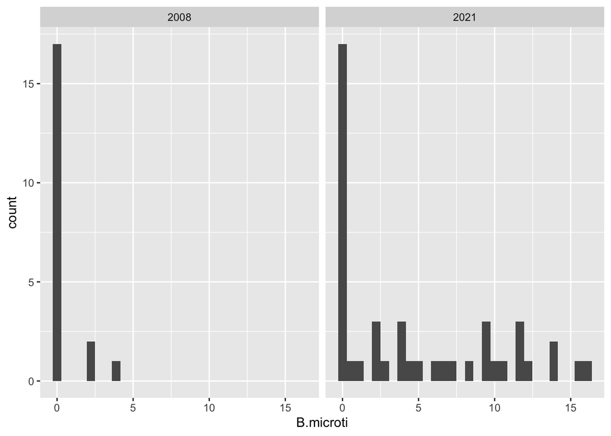

```r
ggplot(data = tick_adult_small, aes(x = B.microti)) +
  geom_histogram() +
  facet_wrap(~Year)
```

There is more spread for 2021, however the peaks both seem to be at or close to 0%. I think this one would show less significance than the other questions regarding bacteria.

This will lead me to run a two-sample t-test with the following hypotheses:

Null Hypothesis: There is no difference in mean B.microti percentage between the years 2008 and 2021. Alternative Hypothesis: There is a difference in mean B.microti percentage between the years 2008 and 2021.

```r
bmicroti_ttest <- t.test(B.microti ~ Year, data = tick_adult_small)
```

## Is there an association between mean B.miyamotoi percentage in the years 2015 and 2021 (there was no data for 2008-2014)?

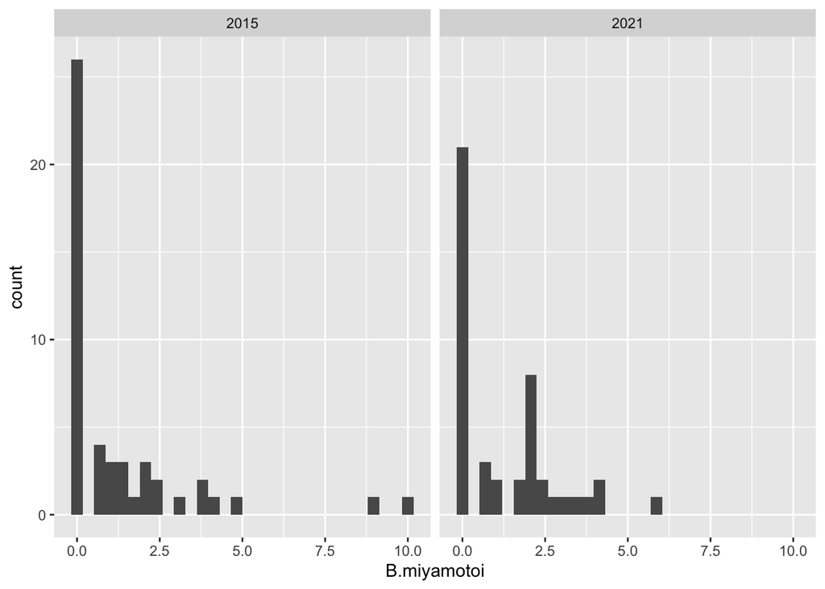

```r
tick_adult_small2 <- tick_adult %>% filter(Year == "2015" | Year == "2021")
ggplot(data = tick_adult_small2, aes(x = B.miyamotoi)) +
  geom_histogram() +
  facet_wrap(~Year)
```

This one is not as obvious that there could be a difference in the means. They both have peaks around zero, however there are some values in 2015 greater than 7.5%, which might make it have a higher mean, and cause the difference to be significance.

This will lead me to run a two-sample t-test with the following hypotheses:

Null Hypothesis: There is no difference in mean B.miyamotoi percentage between the years 2015 and 2021. Alternative Hypothesis: There is a difference in mean B.miyamotoi percentage between the years 2015 and 2021.

```r
bmiya_ttest <- t.test(B.miyamotoi ~ Year, data = tick_adult_small2)
```

# Biological Summary

When looking at region and year, we could see differences in the mean tick population desnity between almost all regions when being compared to the Capital Region, except for Long Island. We would have to look to see if the Capital Region is more urban, however we know for certain that some more rural regions like the North Country, have a signficant difference compared to the Capital Region. The interaction terms are being compared to the Capital Region, and the only non-signficant ones were between year and CNY and Southern Tier. Both of these regions are more rural, with some urban areas. Paul (2016) explained how areas with forests or even now more suburban areas close to forests are experiencing higher tick population density.

# Challenges

I have had to think back to things I have learned in statistics classes up to two years ago. I do not think that I am interpreting the glm model with the interaction terms correctly. It was brought up using interaction terms, however, I think this model has too many parameters, so I focused on 2008 and 2021, and even after that it still has too many parameters.

I think for the first test using year and density, I decided to just use two years, the beginning (2008) and the end (2021) of the data in order to simplify things. I chose not to do a time-series analysis. But if I have more time, I would like to look into that as a possible test, because I think that might be useful especially for data by year.

I think one thing I need to refresh myself on is just what tests to use in each scenario based on what types of data we have. Also, I think we did not really go into too much detail about the statistical assumptions, but I need to look at the normality assumption for the region-density question, as it does not look completely normal on the autoplot.

I am also having trouble findings sources that help to explain my hypotheses, as there is not a lot of data explaining ticks and why they might be more densely population in certain areas. The issue with region is that I cannot really assume that one region is urban versus rural, because Upstate NY in general is quite rural. I might have large cities in those regions, but I do not know exactly where the samples were taken, so it makes this interpretation pretty difficult.

# Works Cited

Kowalec, M., Szewczyk, T., Welc-Falęciak, R., Siński, E., Karbowiak, G., & Bajer, A. (2017). Ticks and the city - are there any differences between city parks and natural forests in terms of tick abundance and prevalence of spirochaetes?. Parasites & vectors, 10(1), 573. https://doi.org/10.1186/s13071-017-2391-2

Paul, R.E.L., Cote, M., Le Naour, E. et al. Environmental factors influencing tick densities over seven years in a French suburban forest. Parasites Vectors 9, 309 (2016). https://doi.org/10.1186/s13071-016-1591-5